## Overview

In this blog we look at a method to estimate where to prioritise your SEO resources by estimating which keywords will increase revenue the most if you could improve their rank.

It uses data from Google Search Console and Google Analytics, with Search Console being used to provide the keywords in these days post (not provided). We then link the two data sets by using the URLs as a key, and estimate how much each keyword made in revenue by splitting them in the same proportion as the traffic they have sent to the page.

This approach assumes each keyword converts at the same rate once on the page, and will work better with some more websites more than others - the best results I have seen are ones with lots of content that capture a lot of long-tail queries as the amount of keywords per URL is small, and with enough traffic to make the estimates trustworthy.

We also try to incorporate magins of error in the results, so to have an idea on which resutls to trust more. This avoids situations where one click on position 40 gets a massive weighting in potential revenue, which in reality could have been a freak event.

## Getting the data

Google Analytics recently provided more integration between the Search Console imports and the web session data, of which [Daniel Waisberg has an excellent walk-through](http://online-behavior.com/analytics/search-console), which could mean you can skip the first part of this script.

However, there are circumstances where the integration won’t work, such as when the URLs in Google Analytics are a different format to Search Console - with the below script you have control on how to link the URLs, by formatting them to look the same.

```r
library(searchConsoleR)
library(googleAnalyticsR)

getOption("googleAuthR.scopes.selected")
options(googleAuthR.scopes.selected = c("https://www.googleapis.com/auth/webmasters",
                                        "https://www.googleapis.com/auth/analytics",
                                        "https://www.googleapis.com/auth/analytics.readonly"))
googleAuthR::gar_auth()
ga_id <- 1111111 ## replace with your GA ID

start <- as.character(Sys.Date() - 93)
end <- "2016-06-01"

## Using new GA v4 API
## GAv4 filters
google_seo <- filter_clause_ga4(list(dim_filter("medium", "EXACT", "organic"),
                                     dim_filter("source", "EXACT", "google")),
                                "AND")

## Getting the GA data
gadata <- google_analytics_4(ga_id,
                             date_range = c(start,end),
                             metrics = c("sessions","transactions","transactionRevenue"),
                             dimensions = c("landingPagePath"),
                             dim_filters = google_seo,
                             order = order_type("transactions",
                                                sort_order = "DESC",
                                                orderType = "VALUE"),
                             max = 20000)

## Getting the Search Console data
scdata <- search_analytics("http://www.example.co.uk",
                           startDate = start, endDate = end,
                           dimensions = c("page","query"),
                           rowLimit = 20000)
```

## Transforming the data

First we chane the URLs into the same format as Google Analytics. In this example, the hostname is appended to the GA URLs already (why the native support won’t work), but you may also need to append them.

We also get the search page result (e.g. Page 1 = 1-10, Page 2 = 11-20) as it may be useful.

For the split of revenue later, the last call calculates the % of clicks going to each URL.

```r
library(dplyr)

## get urls in same format
## gadata has urls www.example.com/pagePath
## scdata has urls in http://www.example.com/pagePath
scdata$page2 <- gsub("http://","", scdata$page)

## get SERP
scdata$serp <- cut(scdata$position,
                   breaks = seq(1, 100, 10),
                   labels = as.character(1:9),
                   include.lowest = TRUE, ordered_result = TRUE)

## % of SEO traffic to each page per keyword
scdata <- scdata %>%
  group_by(page2) %>%
  mutate(clickP = clicks / sum(clicks)) %>%
  ungroup()
```

Now we have the data, it is combined, and we calculate the estimates of revenue, transactions and Revenue. You may also use Goals.

As a guide to how worthwhile this approach is, we also create an accuracy estimate: this compares the sessions as calcualted via estimates verses the real figure from GA. If 0 then it is 100% accuracy, the further away from 0 the figure is the less we trust the results.

```r
library(dplyr)

## join data on page
joined_data <- gadata %>%
  left_join(scdata, by = c(landingPagePath = "page2")) %>%
  mutate(transactionsEst = clickP*transactions,
         revenueEst = clickP*transactionRevenue,
         sessionEst = clickP*sessions,
         accuracyEst = ((sessionEst / clicks) - 1))

## we only want clicks over 0, and get rid of a few columns.
tidy_data <- joined_data %>%
  filter(clicks > 0) %>%
  select(-page, -sessions, -transactions, -transactionRevenue)
```

A histogram of the accuracy estimate shows we consistently over estimate but the clicks and estimated sessions are within a magnitude:

```r
summary(joined_data$accuracyEst)
```

```
##    Min. 1st Qu.  Median    Mean 3rd Qu.    Max.    NA's
##   -0.50    0.50    1.16    2.31    1.37  158.00   40332
```

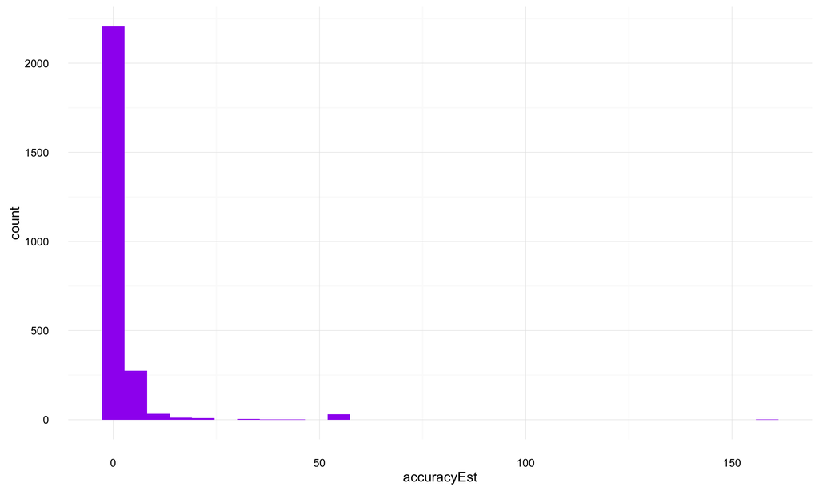

```r
library(ggplot2)
bar_est <- ggplot(joined_data, aes(x = accuracyEst)) + theme_minimal()
bar_est + geom_histogram(fill = "purple")
```

From above I discarded all rows with an accuracy > 10 as unreliable. It may be that daily user’s are more in line with Search Console clicks as its unclear what a defintion of a session is for Google SEO users.

## Creating the SEO forecasts

We now use the data to create a click curve table, with estimates on the CTR for each position, and the confidence in those results.

I first attempted some models on making predictions of click curves for a website, but didn’t find any general satisifactory regressions.

The diagram below uses a weighted `loess` within `ggplot2` which is good to show trend but not for making predictions.

```r
library(ggplot2)
library(plotly)
## CTR per position
ctr_plot <- ggplot(tidy_data, aes(x = position,
                                  y = ctr
                                  ))
ctr_plot <- ctr_plot + theme_minimal() + coord_cartesian(xlim = c(1,30), ylim = c(0, 0.5))
ctr_plot <- ctr_plot + geom_point(aes(alpha = log(clicks),
                                      color = serp,
                                      size = clicks), show.legend = FALSE)
ctr_plot <- ctr_plot + geom_smooth(aes(weight = clicks), size = 0.2, show.legend = FALSE)
ctr_plot <- ctr_plot + scale_y_continuous(labels = scales::percent, name = "CTR")
ctr_plot <- ctr_plot + ggtitle("Click through rate from Google search results.")
plotly::ggplotly(ctr_plot)
```

[interactive chart not shown]

However, 99% of the time we will only be concenred with the top 10, so it wasn’t too taxing to calculate the click through rates per website based on the data they had:

```r
library(dplyr)
model_data$positionRound <- round(model_data$position)


click_curve <- tidy_data %>%
  group_by(positionRound) %>%
  summarise(CTRmean = mean(ctr),
            n = n(),
            click.sum = sum(clicks),
            impressions.sum = sum(impressions),
            sd = sd(ctr),
            E = poisson.test(click.sum)$conf.int[2] / poisson.test(impressions.sum)$conf.int[1],
            lower = max(CTRmean - E,0),
            upper = CTRmean + E) %>% ungroup()

## add % increase to position 1
## could also include other positions
click_curve <- click_curve %>%
  mutate(CTR1 = CTRmean[1] / CTRmean,
         CTR1.upper = upper[1] / upper,
         CTR1.lower = lower[1] / lower)
```

```r
library(plotly)
library(ggplot2)
hh <- ggplot(click_curve, aes(positionRound, CTRmean)) + theme_minimal()

hh <- hh + geom_line(linetype = 2) + coord_cartesian(xlim = c(1, 30), ylim = c(0,0.5))
hh <- hh + geom_ribbon(aes(positionRound, ymin = lower, ymax = upper), alpha = 0.2, fill = "orange")
hh <- hh + scale_y_continuous(labels = scales::percent, name = "CTR")
hh <- hh + geom_point() + geom_label(aes(label = scales::percent(CTRmean)))
hh <- hh + ggtitle("Average Click through rate per position for example.com.")

plotly::ggplotly(hh)
```

[interactive chart not shown]

Once happy with the click curve, we now apply it to the original data, and work out estimates on SEO revenue for each keyword if they were at position 1.

I trust results more if they have had more than 10 clicks, and the accuracy estimate figure is within 10 of 0.

```r
library(dplyr)
## combine with data

predict_click <- tidy_data1 %>%
  mutate(positionRound = round(position)) %>%
  left_join(click_curve, by = c(positionRound = "positionRound")) %>%
  mutate(revenueEst1 = revenueEst * CTR1,
         transEst1 = transactionsEst * CTR1,
         clickEst1 = clicks * CTR1,
         sessionsEst1 = sessionEst * CTR1,
         revenueEst1.lower = revenueEst * CTR1.lower,
         revenueEst1.upper = revenueEst * CTR1.upper,
         revenueEst1.change = revenueEst1 - revenueEst)

estimates <- predict_click %>%
  select(landingPagePath, query, clicks, impressions,
         ctr, position, serp, revenueEst, revenueEst1, revenueEst1.change, revenueEst1.lower, revenueEst1.upper, accuracyEst) %>%
  arrange(desc(revenueEst1)) %>% dplyr::filter(abs(accuracyEst) < 10, revenueEst1.change > 0, clicks > 10)
```

`estimates` now in this example holds 226 rows of the top queries and landing pages sorted in order or how much revenue they are to make if position #1 in Google. This is from an original keyword list of 21437.

## Plotting the data

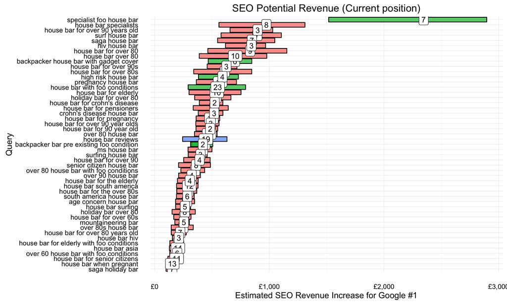

```r
library(ggplot2)


est_plot <- ggplot(estimates[1:50,],
                   aes(reorder(query, revenueEst1),
                       revenueEst1,
                       ymax = revenueEst1.upper,
                       ymin =  revenueEst1.lower))
est_plot <- est_plot + theme_minimal() + coord_flip()
est_plot <- est_plot + geom_crossbar(aes(fill = cut(accuracyEst, 3, labels = c("Good","Ok","Poor"))), alpha = 0.7, show.legend = FALSE)
est_plot <- est_plot + scale_x_discrete(name = "Query")
est_plot <- est_plot + scale_y_continuous(name = "Estimated SEO Revenue Increase for Google #1", labels = scales::dollar_format(prefix = "£"))
# est_plot <- est_plot + theme(axis.text.y = element_blank())
est_plot <- est_plot + geom_label(aes(label = round(position)), hjust = "center")
# est_plot <- est_plot + scale_y_discrete(expand = c(1,1))
est_plot <- est_plot + ggtitle("SEO Potential Revenue (Current position)")

est_plot
```